# ggplot2-2

样式美化

Humoon

2022-03-23

*ggplot2 cheatsheet.pdf*

[figure not shown]

## Labs(绘图区外部的各种元素的标题)

`labs(..., title = , subtitle = , caption = , tag = )`

### 图形标题、副标题和说明

title, 主标题。使用标题的目的是概括主要成果。尽量不要使用那些只对图形进行描述的标题，如”发动机排量与燃油效率散点图”。

subtitle, 副标题。在标题下以更小的字体添加更多附加信息。

caption, 说明，在图形下方添加文本，常用于描述数据来源。

[figure not shown]

```r
ggplot(mpg, aes(displ, hwy)) +
  geom_point(aes(color = class)) +
  geom_smooth(se = FALSE) +
  labs(
    title = paste("Fuel efficiency generally decreases with", "engine size"),
    subtitle = paste(
      "Two seaters (sports cars) are an exception",
      "because of their light weight"
    ),
    caption = "Data from fueleconomy.gov"
  )
```

### 坐标轴和图例的标题

简短的变量名称加单位

[figure not shown]

```r
# 气泡图
ggplot(mtcars, aes(x = wt, y = mpg, size = disp)) +
  # 将disp变量映射为图形的size属性，本例中即为散点的大小。同时生成size图例
  geom_point(shape = 21, color = "black", fill = "cornsilk") +
  # shape=21表示有框圆形（不同于单一颜色的小圆点）
  labs(
    x = "Weight (1000 lbs)", y = "Miles/(US) gallon",
    title = "Bubble Chart",
    size = "Engine\nDisplacement (cu.in.)"
    # size意为对图例添加标签
  )
```

### 使用数学公式代替字符串文本

`quote()`

使用?plotmath命令查看可用选项

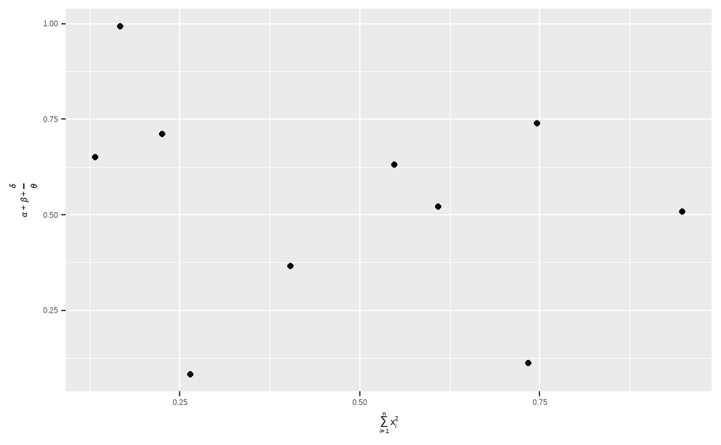

```r
df <- tibble(
  x = runif(10),
  y = runif(10)
)

ggplot(df, aes(x, y)) +
  geom_point() +
  labs(
    x = quote(sum(x[i]^2, i == 1, n)),
    y = quote(alpha + beta + frac(delta, theta))
  )
```

## 绘图区内部的文本标签和说明

`geom_label()`和`ggrepel::geom_label_repel()`在数据旁添加文本标签

`geom_text()`和`ggrepel::geom_text_repel()`在图内添加文本说明

### 数据点旁的标签

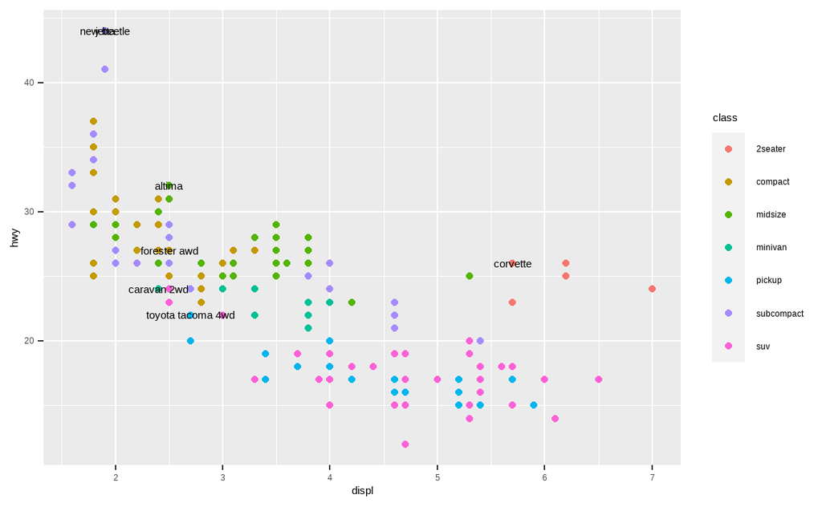

```r
# 先选取出每类汽车中效率最高的型号，然后在图形中标记出来
best_in_class <- mpg %>%
  group_by(class) %>%
  filter(row_number(desc(hwy)) == 1) # desc()排序


ggplot(mpg, aes(displ, hwy)) + # 全局映射和全局数据
  geom_point(aes(color = class)) +
  geom_text(aes(label = model), data = best_in_class) # 用局部数据，将model变量映射为文本标签
```

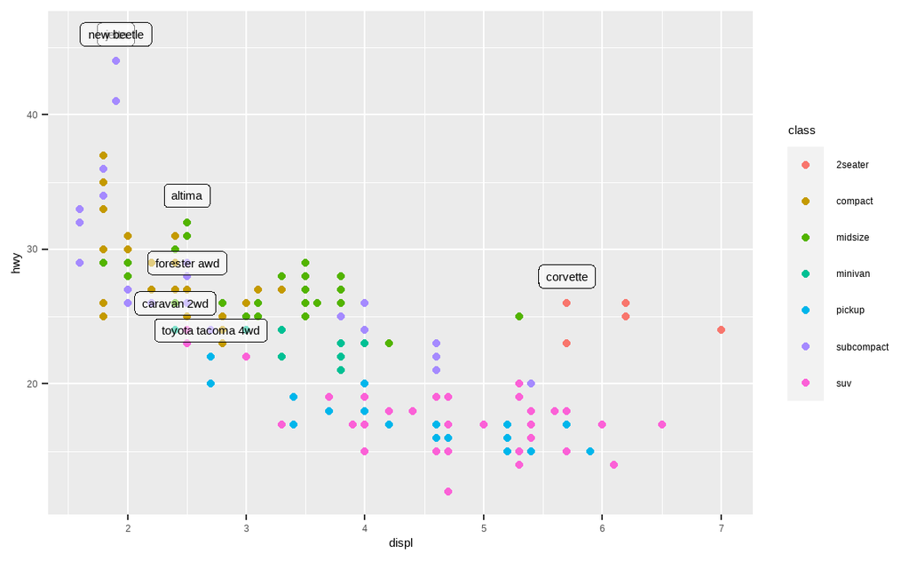

```r
ggplot(mpg, aes(displ, hwy)) +
  geom_point(aes(color = class)) +
  geom_label(aes(label = model),
    data = best_in_class,
    nudge_y = 2, alpha = 0.5
  ) # nudge_y参数可以调整标签相对于数据点的位置
```

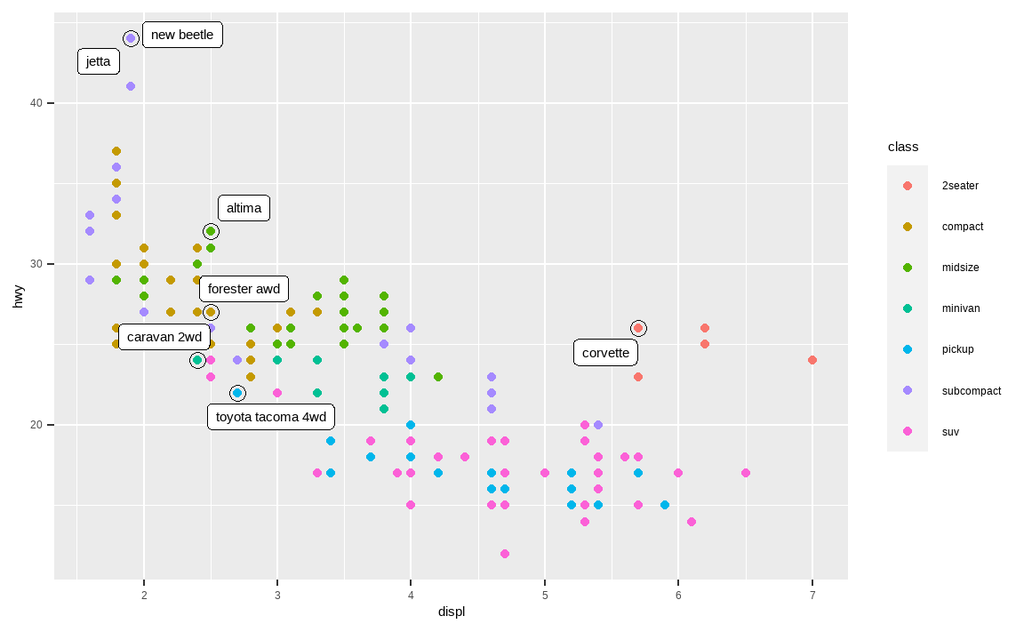

```r
# ggrepel包可以自动调整标签的位置，使它们免于重叠
ggplot(mpg, aes(displ, hwy)) +
  geom_point(aes(color = class)) +
  geom_point(size = 3, shape = 1, data = best_in_class) +
  # 添加了一个图层，用较大的空心圆来强调添加了标签的数据点
  ggrepel::geom_label_repel(aes(label = model), data = best_in_class)
```

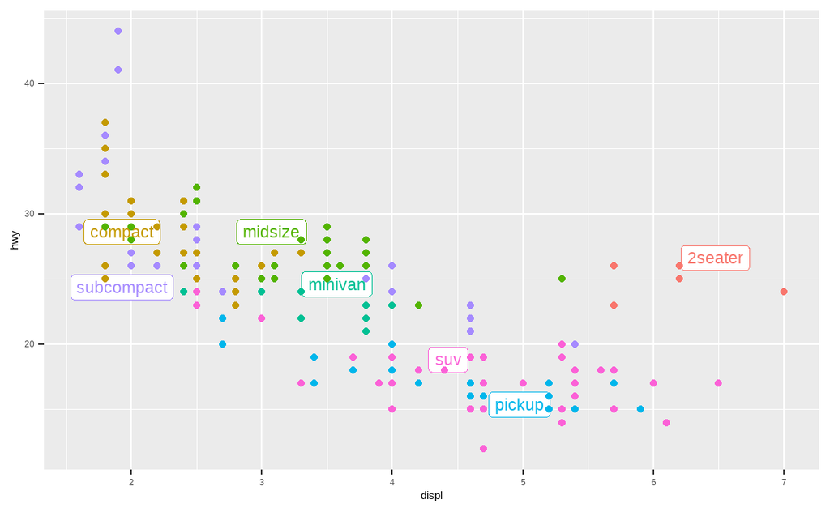

```r
# 将标签直接放在图形上，以替代图例
# 分组，对每组取数据分布的中位数，在该处放置组名
class_avg <- mpg %>%
  group_by(class) %>%
  summarize(displ = median(displ), hwy = median(hwy))

ggplot(mpg, aes(displ, hwy, color = class)) +
  ggrepel::geom_label_repel(
    aes(label = class),
    data = class_avg, size = 6,
    label.size = 0, segment.color = NA
  ) +
  geom_point() +
  theme(legend.position = "none") # 不显示图例
```

### 图中空白处的说明

创建一个数据点，位置在空白处，借这个数据添加标签

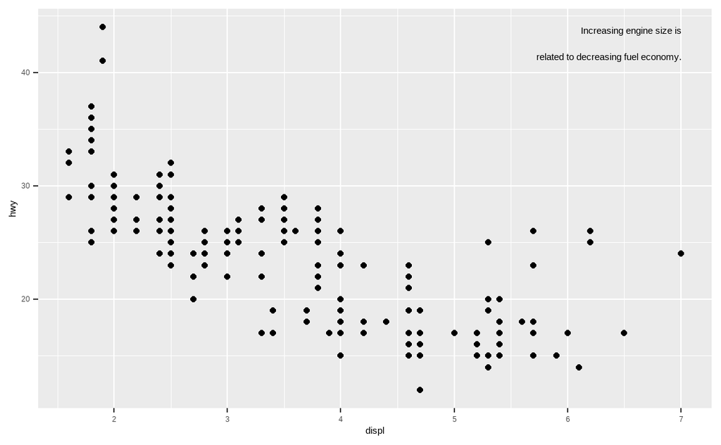

```r
# 创建只有一个观测的数据框，用以保存标签的坐标
label <- mpg %>%
  summarize(
    displ = max(displ), hwy = max(hwy),
    label = paste(
      "Increasing engine size is \nrelated to",
      "decreasing fuel economy."
    )
  )

ggplot(mpg, aes(displ, hwy)) +
  geom_point() +
  geom_text(
    aes(label = label),
    data = label,
    vjust = "top", hjust = "right"
  )
```

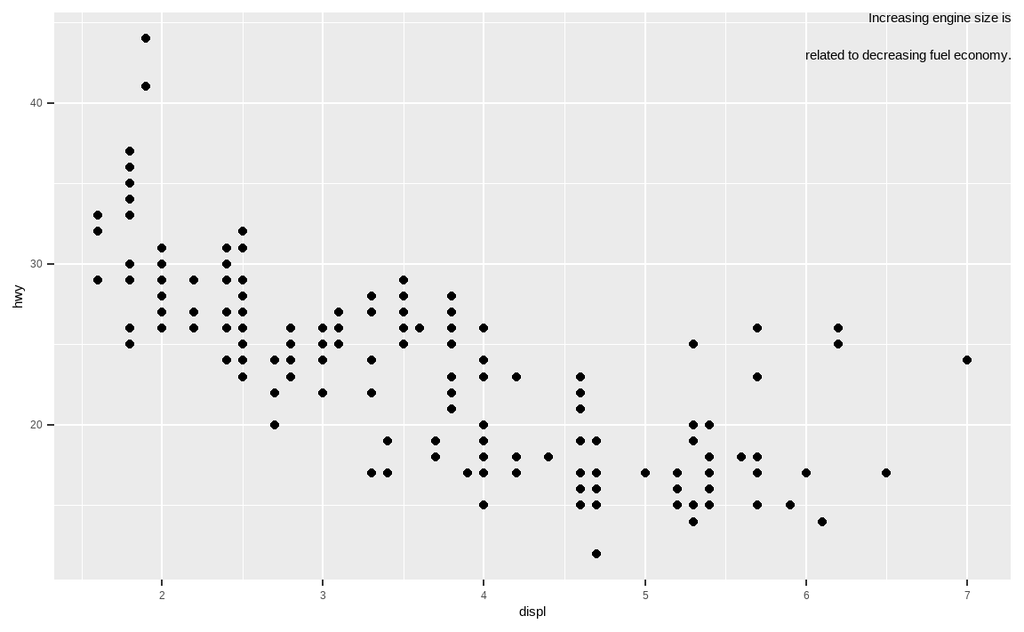

```r
# 如果想让标签紧贴着图形的边界，可以使用+Inf和-Inf值（因为坐标轴的实际范围要比数据范围大一些）
label <- tibble(
  displ = Inf, hwy = Inf,
  label = paste(
    "Increasing engine size is \nrelated to",
    "decreasing fuel economy."
  )
)

ggplot(mpg, aes(displ, hwy)) +
  geom_point() +
  geom_text(aes(label = label), data = label, vjust = "top", hjust = "right")
```

```r
# 自动为标签断行的方法
"Increasing engine size related to decreasing fuel economy." %>%
  stringr::str_wrap(width = 40) %>%
  writeLines()
```

```
#> Increasing engine size related to
#> decreasing fuel economy.
```

### vjust和hjust参数

设置标签相对于坐标的对齐方式

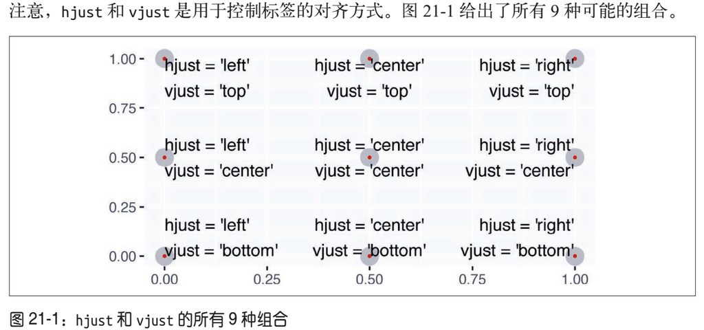

20220323-标签相对于坐标的对齐方式

## 参考线、箭头和方框

- 可以使`用geom_hline(yintercept = 0)`和`geom_vline(xintercept = 0)`添加参考线。我们经常使用加粗（size = 2）和白色（color = white）的直线作为参考线，并将它们绘制在基本数据层的下面。这样的参考线既清晰可见，又不至于喧宾夺主，影响我们查看数据。
- 可以使用`geom_rect()`在我们感兴趣的数据点周围绘制一个矩形。矩形的边界由图形属性 xmin、 xmax、 ymin 和 ymax 确定。
- 可以使用`geom_segment()`及`arrow`参数绘制箭头，指向需要关注的数据点。使用 x 和 y 属性来定义开始位置，使用 xend 和 yend 属性来定义结束位置。

```r
geom_segment(
  x = 6, y = 4, xend = 3, yend = 1, colour = "blue",
  arrow = arrow(angle = 30, length = unit(0.5, "cm"), type = "open")
)
# angle为箭头所张角度，type决定箭头是空心还是实心
```

## 图例 Legends

### guides()

要想控制单个图例的显示，可以配合guide_legend()（负责离散型图例）或guide_colorbar()（负责连续型图例）来使用guides()

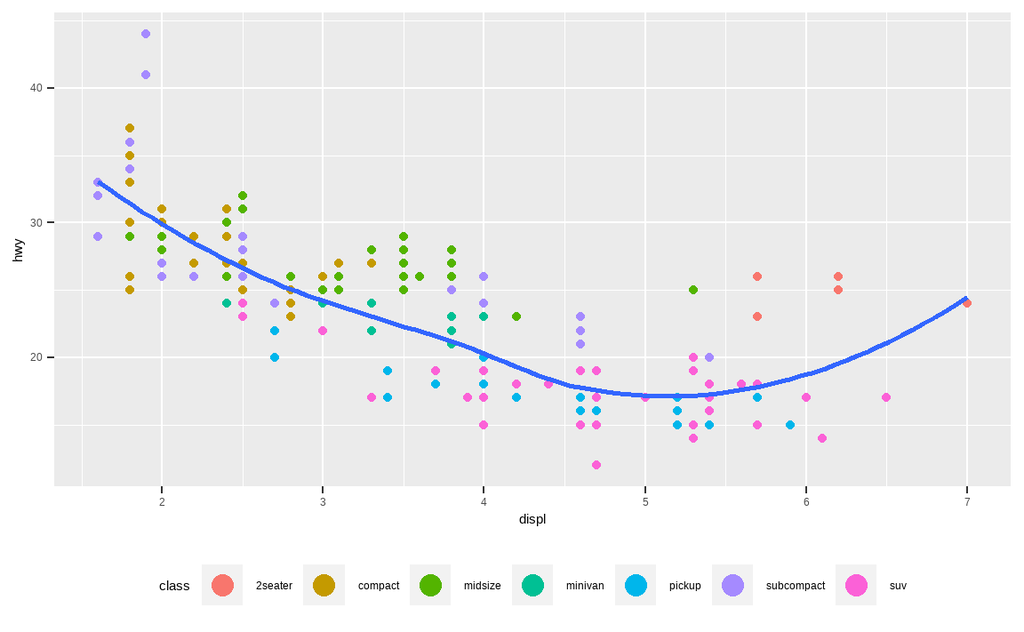

```r
ggplot(mpg, aes(displ, hwy)) +
  geom_point(aes(color = class)) +
  geom_smooth(se = FALSE) +
  theme(legend.position = "bottom") +
  guides(color = guide_legend(nrow = 1, override.aes = list(size = 4)))
```

```r
# nrow使图例排列为1行，size = 4使图例中的数据点更大一些
```

### 图例的位置

theme()中的legend.position参数可以控制图例的整体位置：

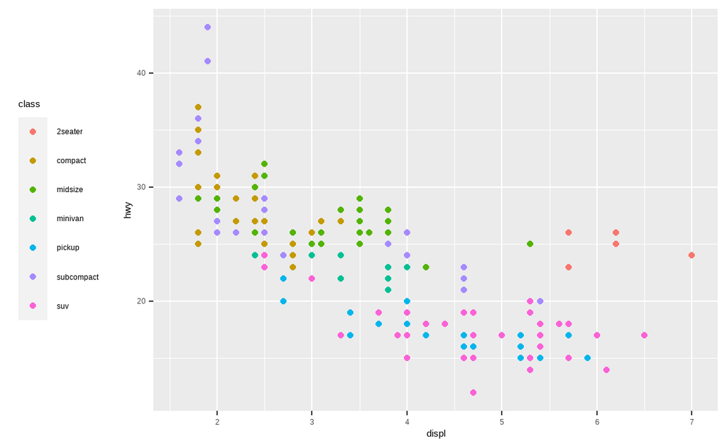

```r
base <- ggplot(mpg, aes(displ, hwy)) +
  geom_point(aes(color = class))

base + theme(legend.position = "left")
```

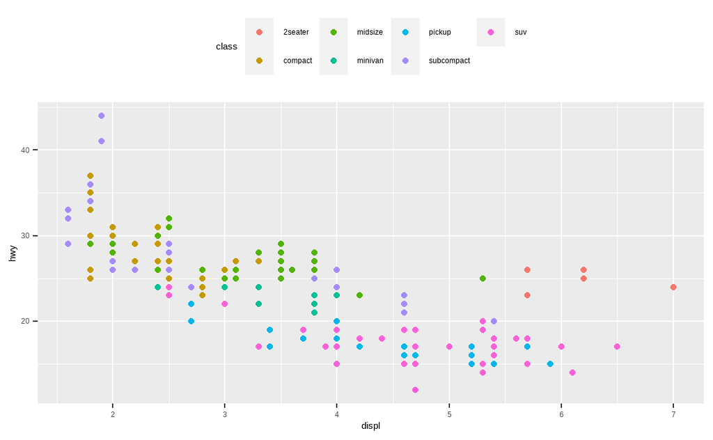

```r
base + theme(legend.position = "top")
```

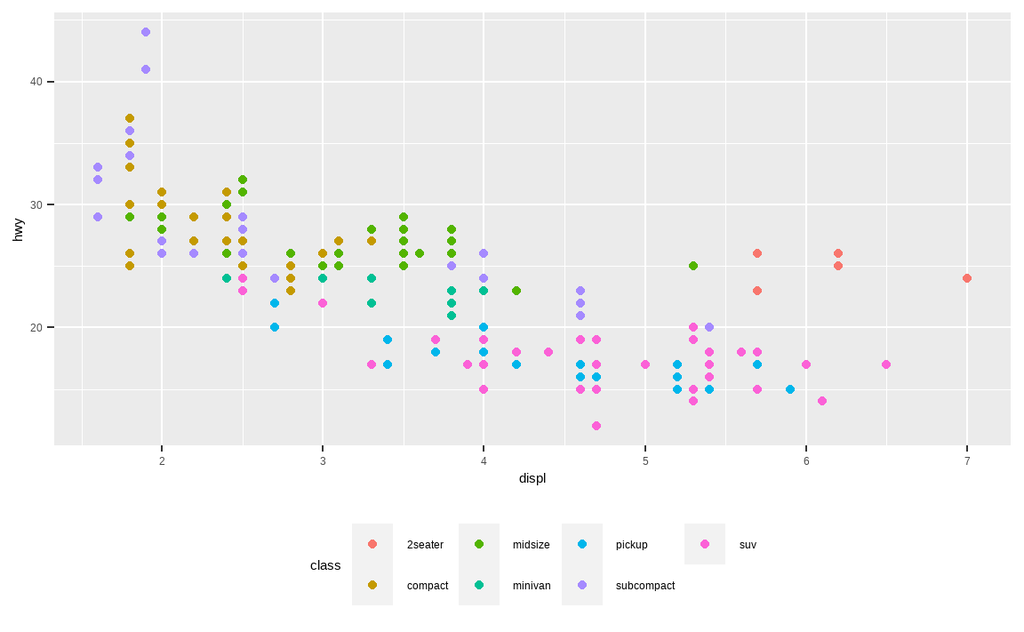

```r
base + theme(legend.position = "bottom")
```

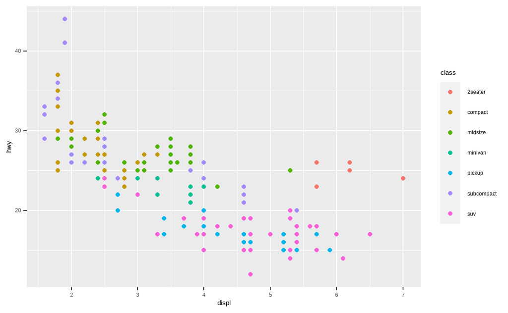

```r
base + theme(legend.position = "right") # 默认设置
```

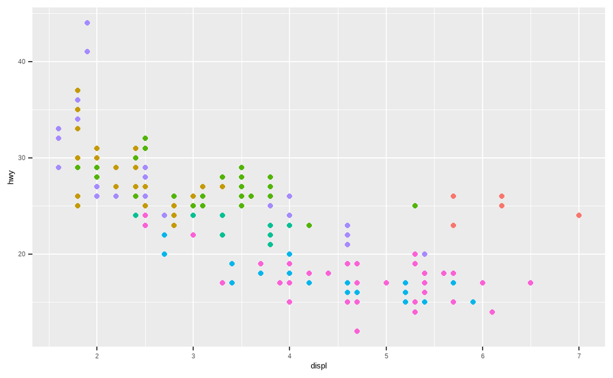

```r
base + theme(legend.position = "none")
```

也可以指定一个二元素向量，表示图例的中心相对于整张图左下角的距离（都用比例表示）

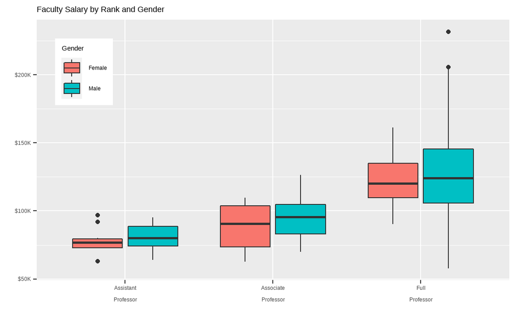

```r
data(Salaries, package = "car")

Salaries %>%
  ggplot(aes(x = rank, y = salary, fill = sex)) +
  geom_boxplot() +
  scale_x_discrete(
    breaks = c("AsstProf", "AssocProf", "Prof"),
    labels = c(
      "Assistant\nProfessor",
      "Associate\nProfessor",
      "Full\nProfessor"
    )
  ) +
  scale_y_continuous(
    breaks = c(50000, 100000, 150000, 200000),
    labels = c("$50K", "$100K", "$150K", "$200K")
  ) +
  labs(
    title = "Faculty Salary by Rank and Gender",
    x = "", y = "", fill = "Gender"
  ) +
  theme(legend.position = c(0.1, 0.8))
```

```r
# 图例中心相对于整张图左下角的距离，0.1和0.8都是相对于整个画面的比例
```

## 主题

theme()可以定制图形中的非数据元素，使图表有自己的风格，在做图表时不考虑格式，最后一次性应用主题。

### ggplot2内置的八种主题

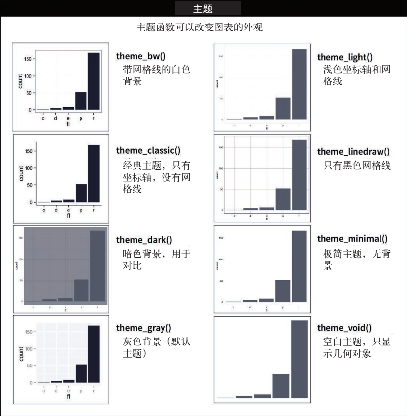

20220323-内置主题

默认主题使用灰色背景，这样可以在网格线可见的情况下更加突出数据。白色网格线既是可见的（这非常重要，因为它们非常有助于位置判定)，又对视觉没有什么严重影响，我们完全可以对其视而不见。图表的灰色背景不像白色背景那么突兀，与文本印刷颜色非常相近，保证了图形与文档其他部分浑然一体。最后，灰色背景可以创建一片连续的颜色区域，使图形成为形象鲜明的一个独立视觉实体。

### 自定义主题

所有可定义的参数可查询`ggplot2::theme()`的帮助文档

| 参数 | 设置的对象 |
| --- | --- |
| plot.title | 图标题 |
| plot.caption | 图标注（一般是资料来源） |
| axis.title | 轴标题 |
| axis.text | 轴须标签 |
| panel.background | 画图区域（fill填充，color边框） |
| panel.grid.major.y | y轴（水平）主要网格线 |
| panel.grid.minor.y | y轴（水平）次要网格线 |
| panel.grid.major.x | x轴（竖直）主要网格线 |
| panel.grid.minor.x | x轴（竖直）次要网格线 |
| legend.position | 图例的位置 |
| legend.title | 图例的标题 |
| legend.text | 图例各项的文字 |

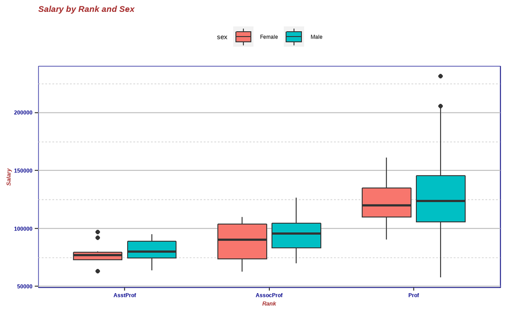

```r
data(Salaries, package = "car")

# 定义自己的主题mytheme
mytheme <-
  theme(
    plot.title = element_text(
      face = "bold.italic",
      size = 14, color = "brown"
    ),
    axis.title = element_text(
      face = "bold.italic", size = 10,
      color = "brown"
    ),
    axis.text = element_text(
      face = "bold", size = 9,
      color = "darkblue"
    ),
    panel.background = element_rect(
      fill = "white",
      color = "darkblue"
    ),
    panel.grid.major.y = element_line(color = "grey", linetype = 1),
    panel.grid.minor.y = element_line(color = "grey", linetype = 2),
    panel.grid.major.x = element_blank(),
    panel.grid.minor.x = element_blank(),
    legend.position = "top"
  )

# 在画图时，应用自己的主题mytheme
ggplot(Salaries, aes(x = rank, y = salary, fill = sex)) +
  geom_boxplot() +
  labs(title = "Salary by Rank and Sex", x = "Rank", y = "Salary") +
  mytheme
```

### 套用现成主题：ggthemes包

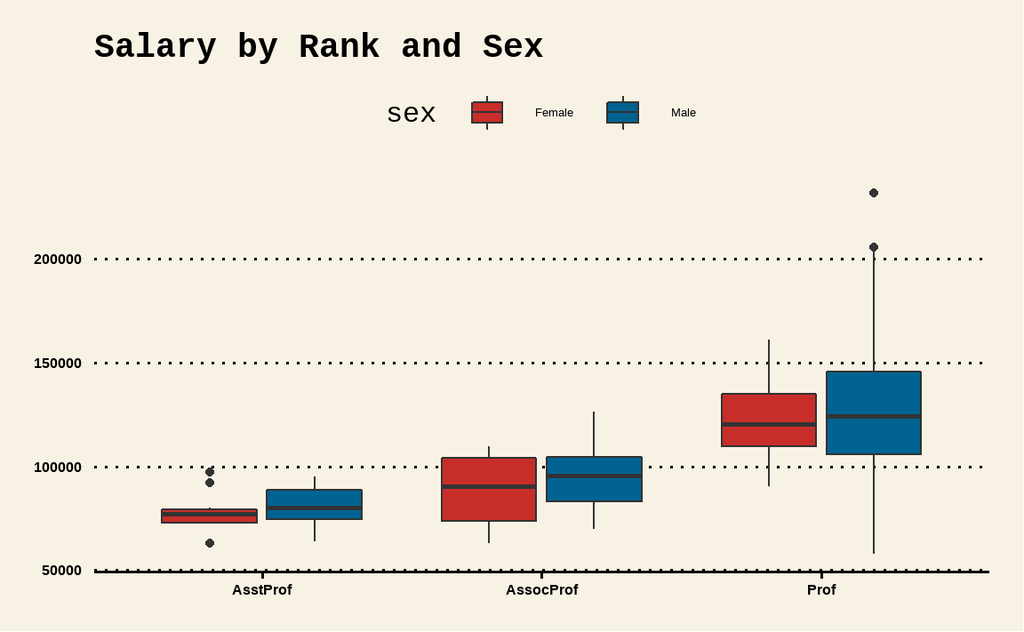

```r
ggplot(Salaries, aes(x = rank, y = salary, fill = sex)) +
  geom_boxplot() +
  labs(title = "Salary by Rank and Sex", x = "Rank", y = "Salary") +
  theme_wsj() +
  scale_fill_wsj()
```

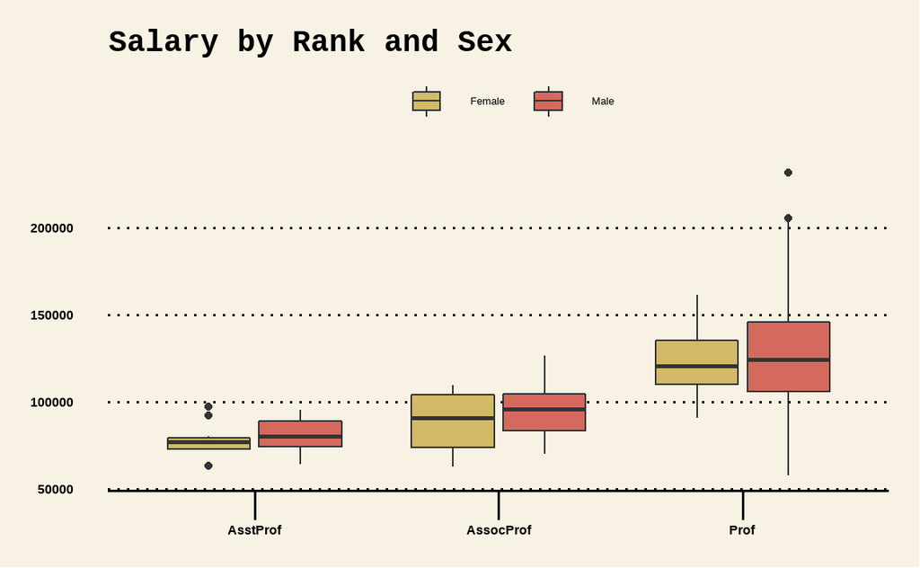

```r
ggplot(Salaries, aes(x = rank, y = salary, fill = sex)) +
  geom_boxplot() +
  labs(title = "Salary by Rank and Sex", x = "Rank", y = "Salary") +
  theme_wsj() +
  scale_fill_wsj("rgby", "") +
  theme(axis.ticks.length = unit(0.5, "cm")) +
  guides(fill = guide_legend(title = NULL))
```

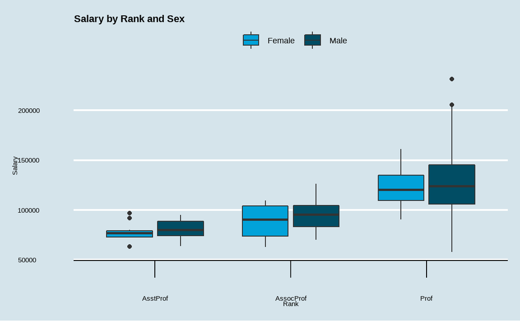

```r
ggplot(Salaries, aes(x = rank, y = salary, fill = sex)) +
  geom_boxplot() +
  labs(title = "Salary by Rank and Sex", x = "Rank", y = "Salary") +
  theme_economist(base_size = 14) +
  scale_fill_economist() +
  theme(axis.ticks.length = unit(0.5, "cm")) +
  guides(fill = guide_legend(title = NULL))
```

## 多图拼接

ggplot2包认为它提供的刻面功能已经足够了。为了组合ggplot图形，需要使用其他包。

### patchwork 包

`(p1/p2)|p3` 表示p1和p2居左，分别上下；p3居右，合并成一幅图

### gridExtra 包

`gridExtra::grid.arrange()`可以组合多幅图

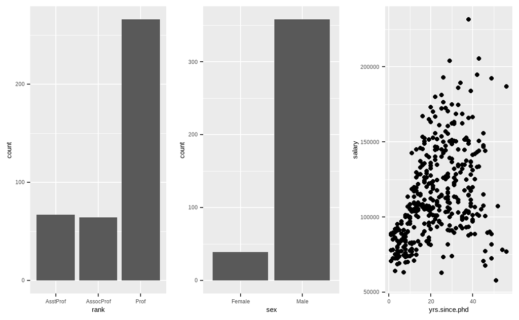

```r
data(Salaries, package = "car")
# ggplot()画的图可以保存为一个对象！
p1 <- ggplot(data = Salaries, aes(x = rank)) +
  geom_bar()
p2 <- ggplot(data = Salaries, aes(x = sex)) +
  geom_bar()
p3 <- ggplot(data = Salaries, aes(x = yrs.since.phd, y = salary)) +
  geom_point()

library(gridExtra)
grid.arrange(p1, p2, p3, ncol = 3)
```

`arrangeGrob()`则可以处理一个由图对象组成的列表（循环作图时很有用）

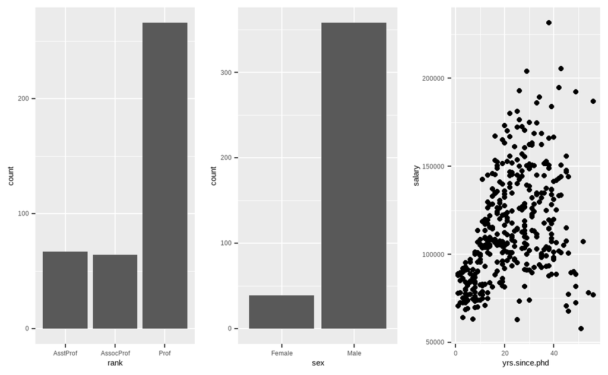

```r
p <- list(p1, p2, p3)
graph <- arrangeGrob(grobs = p, ncol = 3)
grid.arrange(graph)
```

## 配色

### 创建调色板

#### 与色彩相关的函数

| 函数 | 功能 |
| --- | --- |
| palette() | 调色板 |
| colors() | 生成R的颜色 |
| rgb() | 生成颜色编码 |
| col2rgb() | 将字符串颜色转为rgb色值。 |
| rgb2hsv(col2rgb(“blue”)) | 转换为hsv色值 |

#### R自带的六个调色板

传入获取颜色的个数，就获得相应个数的颜色列表，gray()的参数需在[0,1]。

rainbow()

heat.colors()

terrain.colors()

topo.colors()

cm.colors()

gray()

#### RColorBrewer包

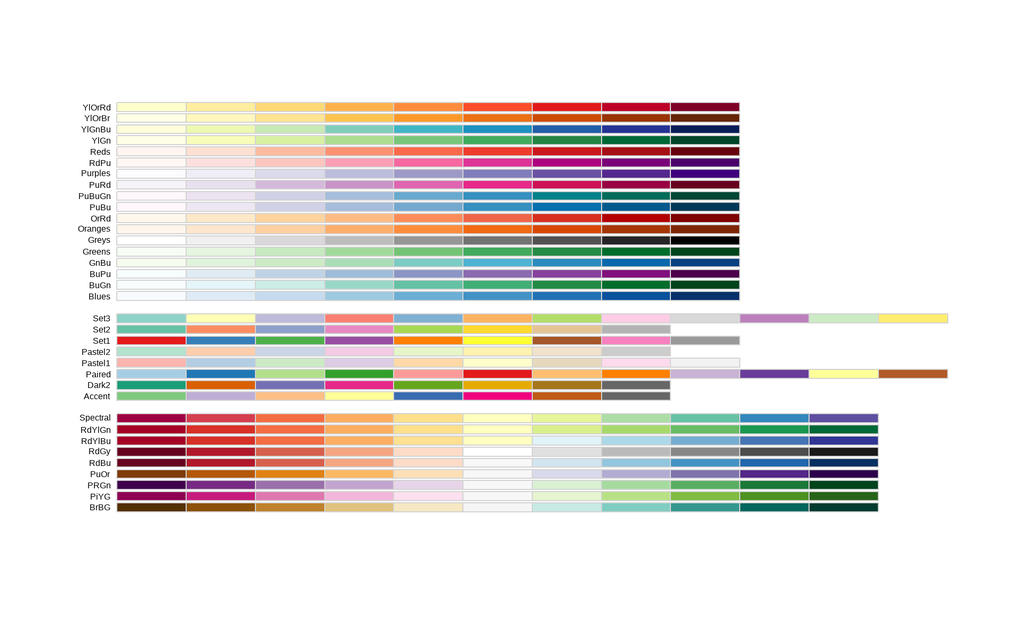

```r
# 通过下列代码观察预先设定的颜色集
library(RColorBrewer)
display.brewer.all()
```

#### ggthemes包

其中的色彩方案都是打包好，命名过的，引用的时候，只需赋值即可。